# sample_from_density()

## Introduction

Behavioral data often exhibit complex patterns that may not adhere to well-known parametric distributions. Traditional statistical methods reliant on such distributions may therefore prove inadequate in capturing the nuanced behaviors observed in real-world scenarios.

Approximating a density distribution from a data sample using Kernel Density Estimation allows researchers to estimate the underlying patterns that could emerge from a specific experiment, thus, the ability to generate synthetic data samples that closely mimic the distribution of observed behavioral data serves as a valuable tool in behavioral analysis. Such samples allow researchers to explore various hypotheses, validate statistical models, and assess the efficacy of experimental interventions in a controlled setting.

Here we introduce the `sample_from_density()` function which generates a given `n` amount of data points from a density distribution calculated using KDE (Kernel Density Estimation) from a given data set.

The function takes two parameters:

- `x` A numeric vector of data points from an distribution.
- `n` the number of samples to return.

## Example

Let’s generate a random sample from a normal distribution:

```r
set.seed(420)
normal_sample <- rnorm(100)
```

Now let’s create a sample of 100 data points from the distribution estimated with the `sample_from_density()` function:

```r
sampled_dist <- sample_from_density(normal_sample, 100)
```

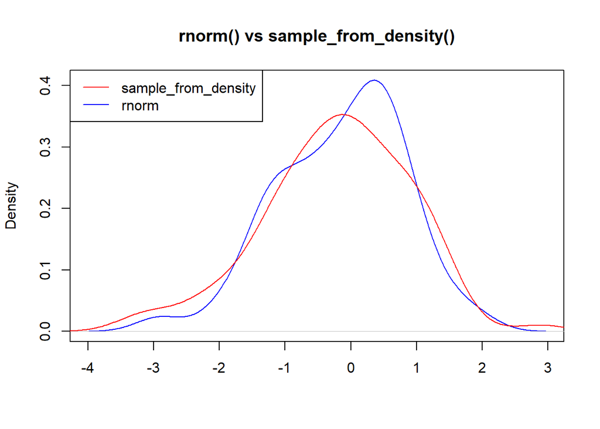